# Lab 13 Activity Key

Author

Published

Invalid Date

### Activity Objectives:

- Multiple Regression

### Instructions:

- Fill in the code chunks
- Render the Quarto document and submit both the `.qmd` and `.html` file on Canvas

## Activity

### 1) If you’d like to load packages with `library()`, please do so in this block. Please load the `NHANES` package. We are going to use the `NHANES` dataset within the `NHANES` package again today. This is a real survey dataset collected by the US National Center for Health Statistics (NCHS) called the National Health and Nutrition Examination Survey.

```r
library(NHANES)
library(tidyverse)
```

### 2) You are a researcher interested in factors associated with poor physical health in adults. Your outcome variable of interest in this dataset is `DaysPhysHlthBad`, the number of days that respondents report having bad physical health days. You are interested in the effect of poor mental health on poor physical health, and you will eventually test the relationship of `DaysMentHlthBad` with `DaysPhysHlthBad`. But, it is common to adjust for gender and age effects, so first: create a cleaned dataset that (1) only contains adult respondants (18 or older), (2) recodes `Gender` into a factor with levels `"male"` adnd `"female"`, and (3) removes rows with `NA`s in any of the four expected model variables. Print the first few rows of the resulting dataset.

```r
NHANES_cleaned <- NHANES |>
  filter(Age >= 18) |>
  mutate(Gender = factor(Gender, levels = c("male", "female"))) |>
  drop_na(DaysPhysHlthBad, DaysMentHlthBad, Gender, Age)
head(NHANES_cleaned)
```

[output not shown]

[output cut: 62 more lines]

### 3) Estimate a simple regression of the effect of gender (`Gender`) on poor physical health days. Print the results of the model in a nice-looking table.

```r
m1 <- lm(DaysPhysHlthBad ~ Gender, data = NHANES_cleaned)
gtsummary::tbl_regression(m1, intercept = TRUE)
```

| **Characteristic** | **Beta** | **95% CI** | **p-value** |
| --- | --- | --- | --- |
| (Intercept) | 3.2 | 2.9, 3.4 | <0.001 |
| Gender |  |  |  |
| male | — | — |  |
| female | 0.66 | 0.29, 1.0 | <0.001 |

Abbreviation: CI = Confidence Interval

### 4) Provide a brief interpretation of the model results.

### 5) Next, add in age (`Age`) as a predictor. Print the results of the model in a nice-looking table.

```r
m2 <- lm(DaysPhysHlthBad ~ Gender + Age, data = NHANES_cleaned)
gtsummary::tbl_regression(m2, intercept = TRUE)
```

| **Characteristic** | **Beta** | **95% CI** | **p-value** |
| --- | --- | --- | --- |
| (Intercept) | 0.49 | -0.05, 1.0 | 0.074 |
| Gender |  |  |  |
| male | — | — |  |
| female | 0.54 | 0.18, 0.91 | 0.003 |
| Age | 0.06 | 0.05, 0.07 | <0.001 |

Abbreviation: CI = Confidence Interval

### 6) Provide a brief interpretation of the results of this new model.

### 7) Finally, add in `DaysMentHlthBad` as a predictor. Print the results of the model in a nice-looking table.

```r
m3 <- lm(DaysPhysHlthBad ~ Gender + Age + DaysMentHlthBad, data = NHANES_cleaned)
gtsummary::tbl_regression(m3, intercept = TRUE)
```

| **Characteristic** | **Beta** | **95% CI** | **p-value** |
| --- | --- | --- | --- |
| (Intercept) | -0.65 | -1.2, -0.11 | 0.018 |
| Gender |  |  |  |
| male | — | — |  |
| female | 0.22 | -0.14, 0.57 | 0.2 |
| Age | 0.07 | 0.06, 0.08 | <0.001 |
| DaysMentHlthBad | 0.23 | 0.21, 0.26 | <0.001 |

Abbreviation: CI = Confidence Interval

### 8) Provide a brief interpretation of the results of this model. Specifically, compare the coefficients to the results from the previous models.

### 9) Conduct diagnostic checks for this model. Examine: normality of residuals, homoscedascticity of residuals, outliers, and multicollinearity. Provide a brief statement as to whether or not the assumptions seem to be met.

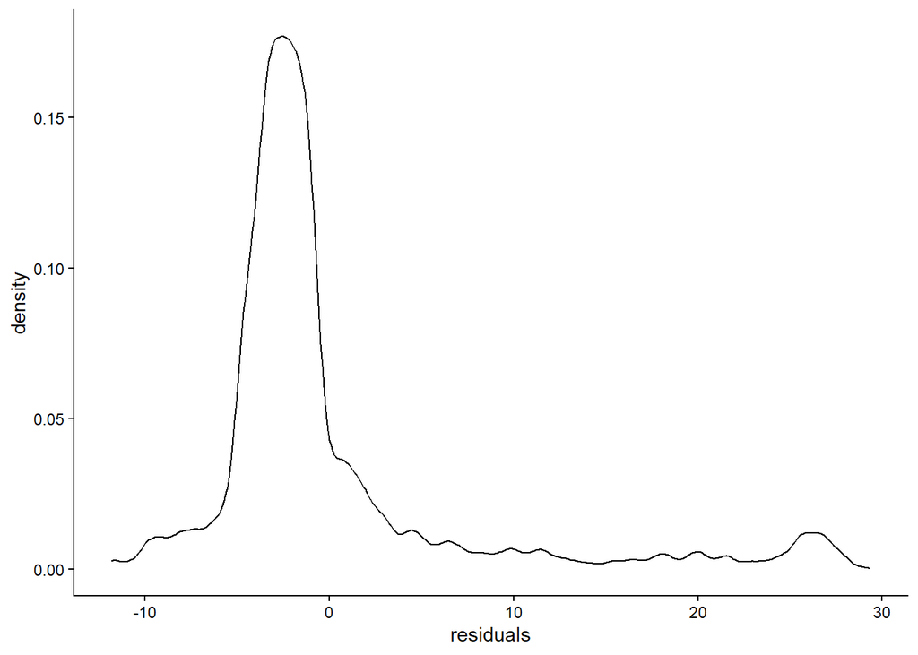

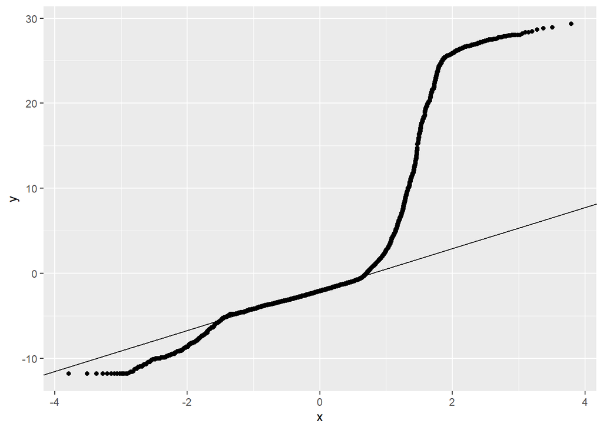

```r
NHANES_cleaned |>
  add_column(residuals = residuals(m3)) |>
  ggplot(aes(x = residuals)) +
  geom_density() +
  theme_classic()
NHANES_cleaned |>
  add_column(residuals = residuals(m3)) |>
  ggplot(aes(sample = residuals)) +
  geom_qq() +
  geom_qq_line()
```

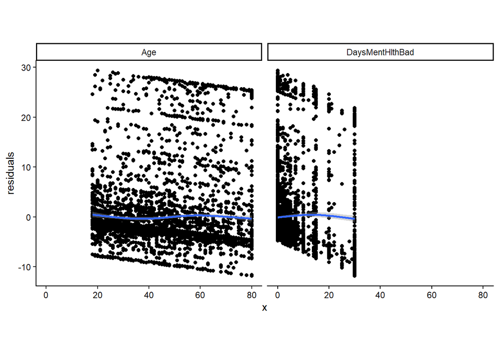

```r
NHANES_cleaned |>
  add_column(residuals = residuals(m3)) |>
  pivot_longer(any_of(names(coef(m3))),
               names_to = "predictor", values_to = "x") |>
  ggplot(aes(x = x, y = residuals)) +
  geom_point() +
  geom_smooth() +
  facet_wrap("predictor") +
  theme_classic() +
  theme(aspect.ratio = 1)
```

```r
n_parameters <- length(coef(m3)) - 1
n_observations = nrow(NHANES_cleaned)

cutoff <- 2 * sqrt((n_parameters + 1) / n_observations)
n_parameters; n_observations
```

```
[1] 3
```

```
[1] 6701
```

```r
cutoff
```

```
[1] 0.04886413
```

```r
high_dffits <- NHANES_cleaned |>
  mutate(dffits = dffits(m3)) |>
  filter(dffits > cutoff)

high_dffits |>
  select(DaysPhysHlthBad, DaysMentHlthBad, Gender, Age, dffits)
```

```
    DaysPhysHlthBad DaysMentHlthBad Gender Age     dffits
1                30              10   male  28 0.08294017
2                30              30 female  76 0.12008519
3                23              30   male  63 0.07911496
4                30              30 female  27 0.12948800
5                30               0 female  62 0.07624266
6                30               0 female  74 0.09108088
7                30               0   male  61 0.07552268
8                30               0   male  61 0.07552268
9                30               0   male  61 0.07552268
10               30               5 female  33 0.07433360
11               30              15   male  32 0.08847903
12               15               0 female  18 0.05507506
13               30              30 female  24 0.13251536
14               30              30 female  24 0.13251536
```

[output cut: 450 more lines]

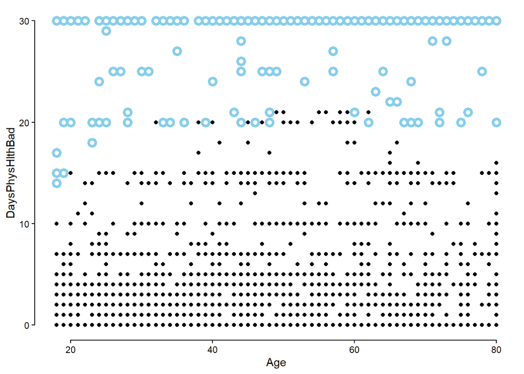

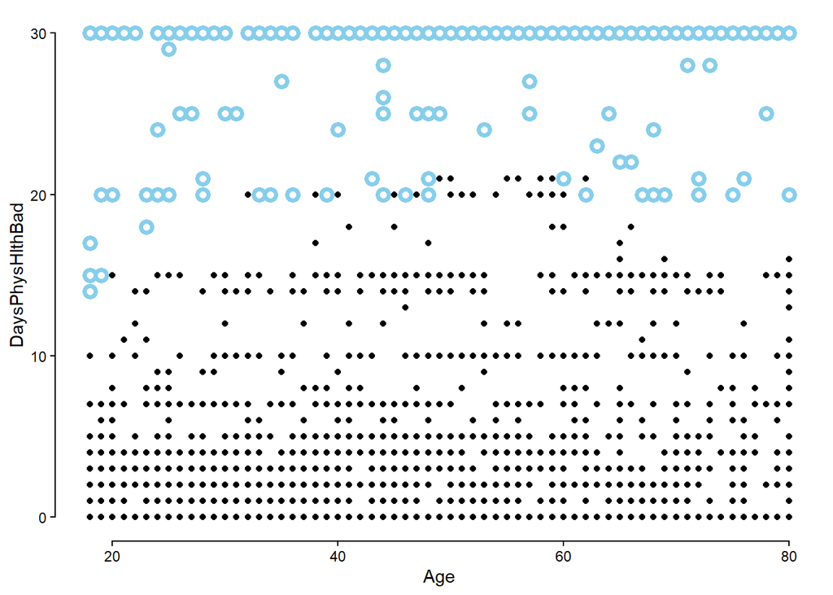

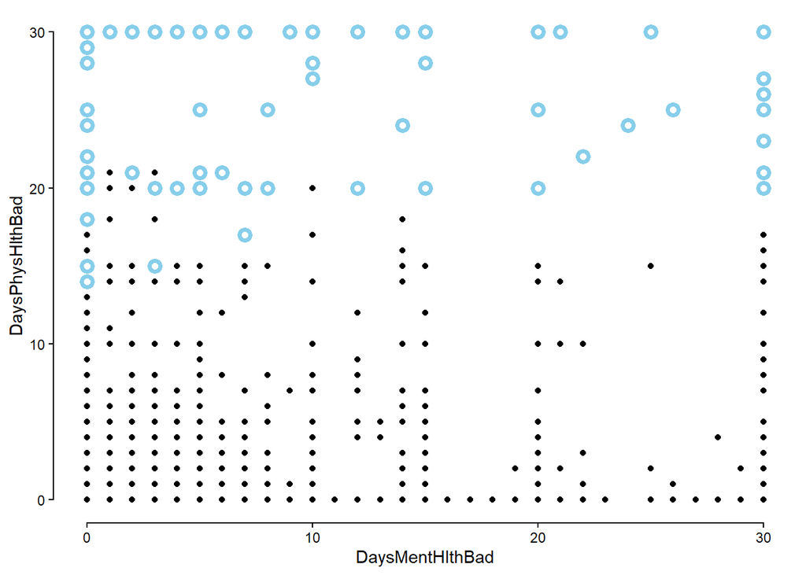

```r
NHANES_cleaned |>
  ggplot(aes(x = Age, y = DaysPhysHlthBad)) +
  geom_point() +
  geom_point(
    data = high_dffits,
    color = "skyblue", fill = "white",
    shape = 21, size = 2, stroke = 2
  ) +
  theme_classic() +
  guides(x = guide_axis(cap = T),
         y = guide_axis(cap = T))
NHANES_cleaned |>
  ggplot(aes(x = Age, y = DaysPhysHlthBad)) +
  geom_point() +
  geom_point(
    data = high_dffits,
    color = "skyblue", fill = "white",
    shape = 21, size = 2, stroke = 2
  ) +
  theme_classic() +
  guides(x = guide_axis(cap = T),
         y = guide_axis(cap = T))
NHANES_cleaned |>
  ggplot(aes(x = DaysMentHlthBad, y = DaysPhysHlthBad)) +
  geom_point() +
  geom_point(
    data = high_dffits,
    color = "skyblue", fill = "white",
    shape = 21, size = 2, stroke = 2
  ) +
  theme_classic() +
  guides(x = guide_axis(cap = T),
         y = guide_axis(cap = T))
```

```r
car::vif(m3)
```

```
         Gender             Age DaysMentHlthBad
       1.010725        1.007122        1.011011
```

### 10) Display the model results visually via its predicted values.

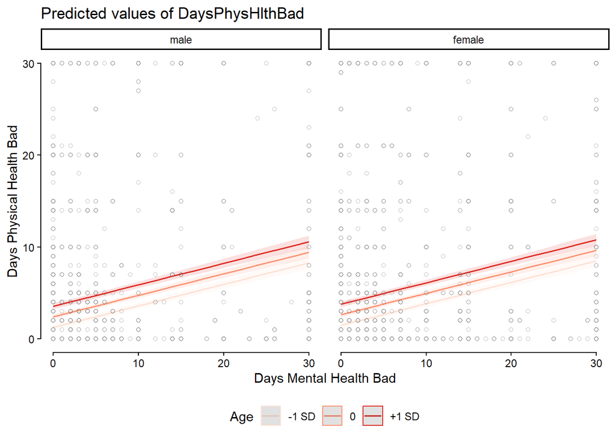

```r
ggeffects::ggpredict(m3, terms = c("DaysMentHlthBad", "Age", "Gender")) |>
  plot() +
  geom_point(
    data = NHANES_cleaned |> mutate(facet = Gender), # needs to match ggpredict's name
    aes(x = DaysMentHlthBad, y = DaysPhysHlthBad),
    inherit.aes = FALSE,
    shape = 21,
    alpha = 0.4,
    color = "grey40"
  ) +
  scale_color_discrete(
    "Age",
    palette = "Reds",
    aesthetics = c("color", "fill"),
    labels = c("-1 SD", "0", "+1 SD")
  ) +
  theme_classic() +
  guides(x = guide_axis("Days Mental Health Bad", cap = T),
         y = guide_axis("Days Physical Health Bad", cap = T)) +
  theme(legend.position = "bottom")
```